# Good Books for Ampersand Cafe & Bookstore

Project 3

520326356

University of Sydney | DATA1001 | October 2022

# Client Bio and Recommendation

> **Client Name:** Ampersand Café & Bookstore

> **Client Bio:** Ampersand Café & Bookstore is Sydney’s best-loved cafe and bookstore serving both exceptional victuals and an extensive selection of books. See more on [Company Website](http://cafebookshop.com.au/), [Instagram](https://www.instagram.com/ampersandcafe/), [Online Book Store](https://www.abebooks.com/).

> **Research Questions:** “What Makes Your Café Stand Out?”

> **Recommendation:** The report recommends enlivening the cafe by offering the highest rated books, thereby attracting consumers to stay longer and increasing the cafe’s sales.

```r
# Load packages
library(readxl)
library(tidyverse)
library(ggplot2)
library(dplyr)
library(kableExtra)
library(DT)
library("cowplot")
```

# Evidence

```r
# import xlsx dataset
books <- read_excel("books.xlsx")
```

### Initial Data Analysis (IDA)

##### **Data Source**

Dataset was retrieved from Kaggle [Goodreads-books](https://www.kaggle.com/datasets/jealousleopard/goodreadsbooks?resource=download).

##### **Data Cleaning**

Several variables were removed from dataset since no useful insight provided, including *bookID*, *isbn*, *publication_date.* See [Original Dataset](https://www.kaggle.com/datasets/jealousleopard/goodreadsbooks?resource=download) for more.

##### **Dataset Structure**

```r
# create date frame which explains variables & data structures
books_df <- data.frame(
  Variables = c("Title","Authors","Average Rating", "ISBN13",
                "Language Code", "Ratings Count",
                "Text Reviews Count","Publisher"
                ),
  Description = c(
    "Title of the book. ",
    "Name of author. ",
    "Overall average rating of the book. ",
    "13-digit ISBN identification of the book. ",
    "Primary language of the book. ",
    "Total number of ratings received by the book. ",
    "Total number of written text reviews received by the book. ",
    "Name of publisher. "
    ),
  Format = c("Text", "Text", "Numeric", "Alphanumeric",
             "Text", "Numeric", "Numeric", "Text"))

# table formatting
kbl(books_df, caption = "Table 1: Details of Variables") %>%
  kable_styling(bootstrap_options = c("striped", "hover")) %>%
  column_spec(1, bold = T, border_right = T)
```

Table 1: Details of Variables

| Variables | Description | Format |
| --- | --- | --- |
| Title | Title of the book. | Text |
| Authors | Name of author. | Text |
| Average Rating | Overall average rating of the book. | Numeric |
| ISBN13 | 13-digit ISBN identification of the book. | Alphanumeric |
| Language Code | Primary language of the book. | Text |
| Ratings Count | Total number of ratings received by the book. | Numeric |
| Text Reviews Count | Total number of written text reviews received by the book. | Numeric |
| Publisher | Name of publisher. | Text |

##### **Limitations**

Limited variables are available for drawing insight as lack of reliable data, which this report relied on inadequate key variables for analysis. Quality of data are poor since irrelevant data existed in some of the dataset’s columns causing poor decisions

# Statistical Analysis

## Average Rating

Recognizing the best-rated books is focused with average_rating. Books rating at maximum of 5 are selected from range of 0 to 5. Details of the selected books are listed in Table 2.

```r
# filter books for highest average_rating
Top_Ratings <- filter(books, average_rating == 5)

# create table with selected variables
datatable(caption = "Table 2: Details of Top Highest Rated Books", Top_Ratings %>%
            select(title, authors, average_rating, isbn13, language_code, num_pages,
                   ratings_count, text_reviews_count, publisher))
```

|  | title | authors | average_rating | isbn13 | language_code | num_pages | ratings_count | text_reviews_count | publisher |
| --- | --- | --- | --- | --- | --- | --- | --- | --- | --- |
| 1 | Comoediae 1: Acharenses/Equites/Nubes/Vespae/Pax/Aves | Aristophanes/F.W. Hall/W.M. Geldart | 5 | 9780198145042 | grc | 364 | 0 | 0 | Oxford University Press USA |
| 2 | Willem de Kooning: Late Paintings | Julie Sylvester/David Sylvester | 5 | 9783829602266 | eng | 83 | 1 | 0 | Schirmer Mosel |
| 3 | Literature Circle Guide: Bridge to Terabithia: Everything You Need For Successful Literature Circles That Get Kids Thinking Talking Writingâ€”and Loving Literature | Tara MacCarthy | 5 | 9780439271714 | eng | 32 | 4 | 1 | Teaching Resources |
| 4 | Middlesex Borough (Images of America: New Jersey) | Middlesex Borough Heritage Committee | 5 | 9780738511672 | eng | 128 | 2 | 0 | Arcadia Publishing |
| 5 | Zone of the Enders: The 2nd Runner Official Strategy Guide | Tim Bogenn | 5 | 9780744002355 | eng | 128 | 2 | 0 | BradyGames |
| 6 | The Diamond Color Meditation: Color Pathway to the Soul | John Diamond | 5 | 9781890995522 | eng | 74 | 5 | 3 | Square One Publishers |
| 7 | Bulgakov's the Master and Margarita: The Text as a Cipher | Elena N. Mahlow | 5 | 9780533017423 | eng | 202 | 4 | 0 | Vantage Press |
| 8 | The Complete Theory Fun Factory: Music Theory Puzzles and Games for the Early Grades | Ian Martin/Katie Elliott | 5 | 9780851621814 | eng | 96 | 1 | 0 | Boosey &amp; Hawkes Inc |
| 9 | The Goon Show Volume 4: My Knees Have Fallen Off! | NOT A BOOK | 5 | 9780563388692 | eng | 2 | 3 | 0 | BBC Physical Audio |
| 10 | The Goon Show Volume 11: He's Fallen in the Water! | NOT A BOOK | 5 | 9780563388326 | eng | 2 | 2 | 0 | BBC Physical Audio |

[output cut: 12 more lines]

## Language Code

Primary language is signification too. Referring to Table 2, it is clear that majority of books has a primary language of English. Hence, relationship between average_rating and language_code was studied.

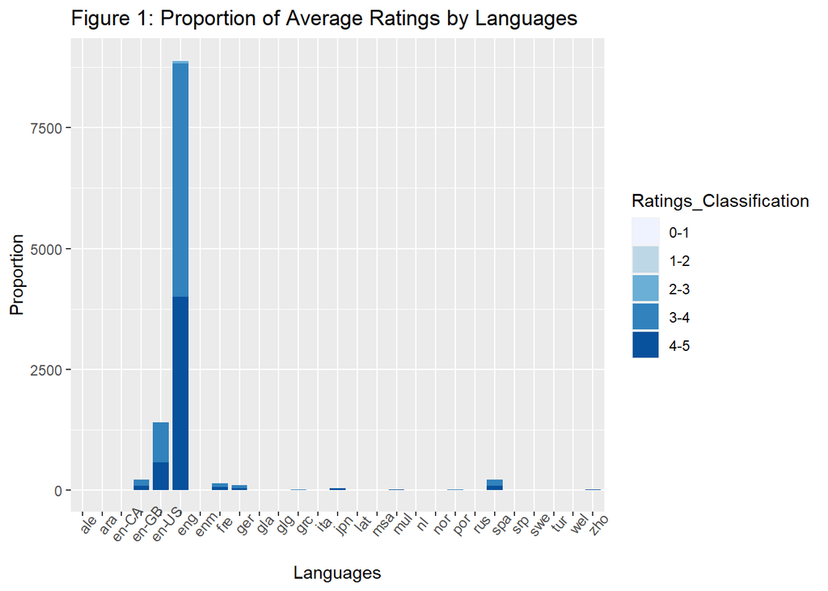

```r
# select average_rating and language_code column from books
Ratings = books$average_rating
Language = books$language_code

# group ratings
FLTRA <- 0 <= Ratings & Ratings <1
FLTRB <- 1 <= Ratings & Ratings <2
FLTRC <- 2 <= Ratings & Ratings <3
FLTRD <- 3 <= Ratings & Ratings <4
FLTRE <- 4 <= Ratings & Ratings <=5

# create a vector which translates ratings into categorical values.
Ratings_Classification <- NULL
Ratings_Classification[FLTRA] <- "0-1"
Ratings_Classification[FLTRB] <- "1-2"
Ratings_Classification[FLTRC] <- "2-3"
Ratings_Classification[FLTRD] <- "3-4"
Ratings_Classification[FLTRE] <- "4-5"

# stacked proportion bar-plot
df <- data.frame(Ratings, Ratings_Classification, Language)

df %>%
  # filter out 'NA' values
  filter(!is.na(Ratings_Classification)) %>%
  ggplot() +
  geom_bar(mapping = aes(x = Language,
                         fill = Ratings_Classification),
           position = "stack",
           width = 0.8) +
  labs(y = "Proportion",
       x = "Languages",
       title = "Figure 1: Proportion of Average Ratings by Languages") +
  # color theme for the graph
  scale_fill_brewer() +
  # customize x-axis
  theme(axis.text.x = element_text(angle = 50))
```

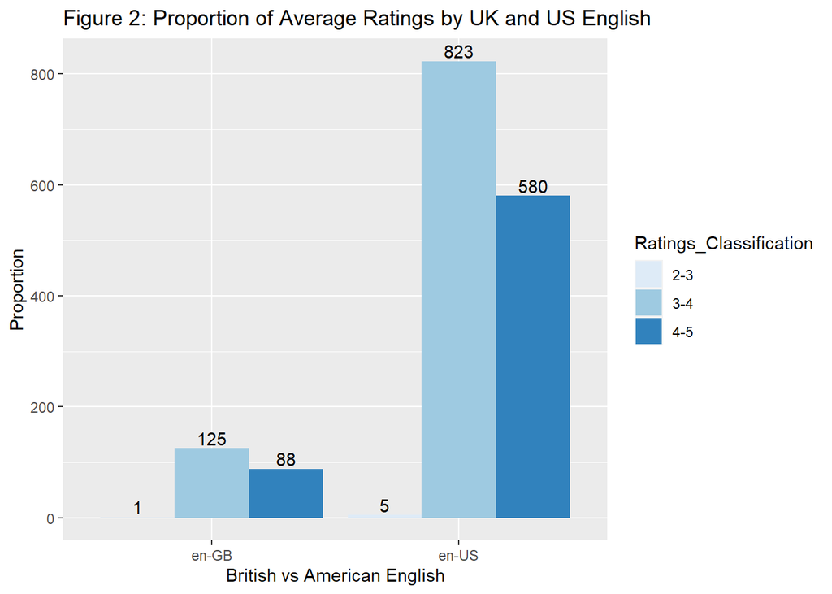

```r
# filter books for "en-US" and "en-GB"
Filtered_Language <- filter(books, language_code == "en-US" | language_code == "en-GB")

Ratings = Filtered_Language$average_rating
Language = Filtered_Language$language_code

# group ratings
FLTRA <- 0 <= Ratings & Ratings <1
FLTRB <- 1 <= Ratings & Ratings <2
FLTRC <- 2 <= Ratings & Ratings <3
FLTRD <- 3 <= Ratings & Ratings <4
FLTRE <- 4 <= Ratings & Ratings <=5

# create a vector which translates ratings into categorical values.
Ratings_Classification <- NULL
Ratings_Classification[FLTRA] <- "0-1"
Ratings_Classification[FLTRB] <- "1-2"
Ratings_Classification[FLTRC] <- "2-3"
Ratings_Classification[FLTRD] <- "3-4"
Ratings_Classification[FLTRE] <- "4-5"

# dodged proportion bar-plot
df <- data.frame(Ratings, Ratings_Classification, Filtered_Language)

ggplot(Filtered_Language, aes(x = language_code,
                              fill = Ratings_Classification)) +
  geom_bar(position = "dodge") +
  labs(y = "Proportion",
       x = "British vs American English",
       title = "Figure 2: Proportion of Average Ratings by UK and US English") +
  # data label
  geom_text(aes(label = ..count..),
            stat = "count",
            position = position_dodge(width=0.9),
            vjust = -0.25) +
  scale_fill_brewer()
```

As seen above, books with both British or American English are more common among the consumers, according to the rating categories between 3-4 and 4-5.

> English language is the most preferred primary language.

## Text Review Count

Number of text reviews is another essential consideration. To investigate how closely text_review_count are related to average_rating, this can be done by determining the strength of the relationship between both variables.

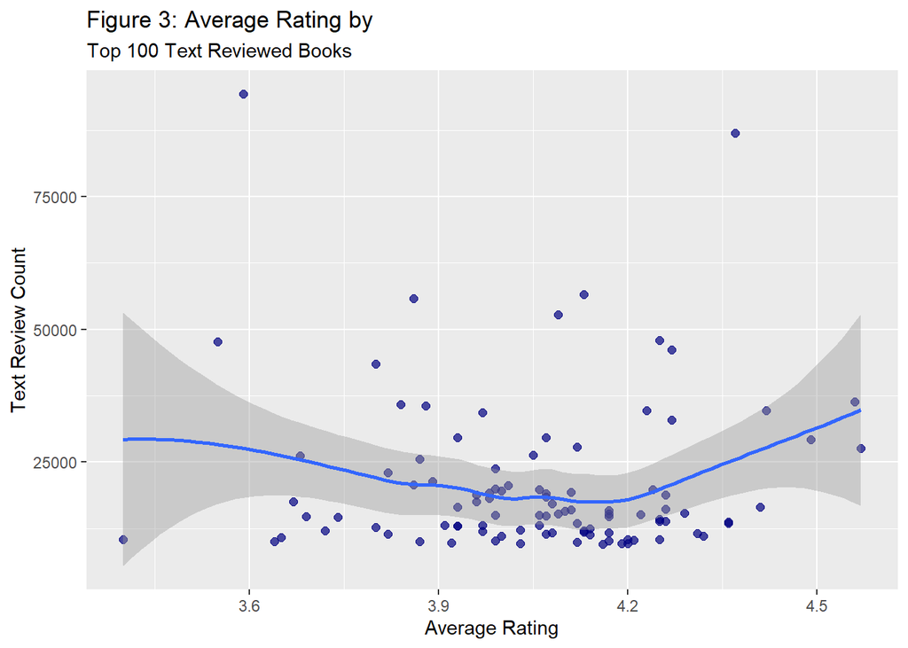

```r
# sort books by top 100 text reviews count
Sorted_Books = books %>%
  arrange(desc(text_reviews_count)) %>%
  head(100)

Ratings = Sorted_Books$average_rating
Text_Review = Sorted_Books$text_reviews_count

# ggplot with Regression Line
# ggplot with Regression Line
ggplot(Sorted_Books, aes(x = Ratings, y = Text_Review)) +
  geom_point(color = "Navy",
             size = 2,
             alpha = .7) +
  geom_smooth() +
  labs(y = "Text Review Count",
       x = "Average Rating",
       title = "Figure 3: Average Rating by " ,
       subtitle = "Top 100 Text Reviewed Books")
```

The plot show visually that the majority of text_review_count focused among average rating of 4.

## Number of Pages Count

Number of pages count may somehow affects a book’s rating and consequently affect consumers’ buying behaviors. The relationship between num_pages and average_rating was recorded in Figure 4.

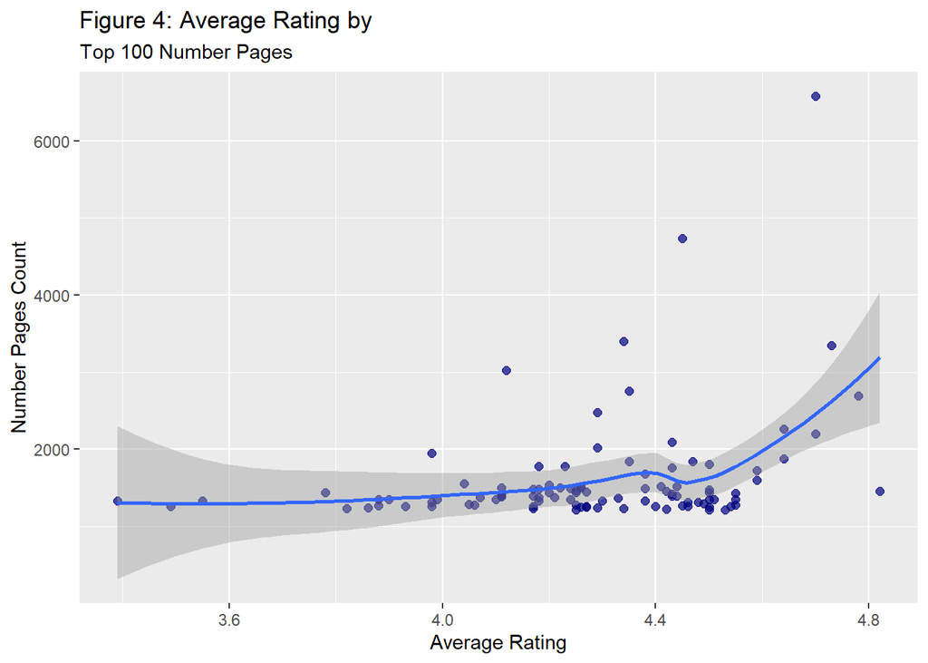

```r
# sort books by top 100 text reviews count
Sorted_Books = books %>%
  arrange(desc(num_pages)) %>%
  head(100)

Ratings = Sorted_Books$average_rating
Num_Pages = Sorted_Books$num_pages

# ggplot with Regression Line
ggplot(Sorted_Books, aes(x = Ratings, y = Num_Pages)) +
  geom_point(color = "Navy",
             size = 2,
             alpha = .7) +
  geom_smooth() +
  labs(y = "Number Pages Count",
       x = "Average Rating",
       title = "Figure 4: Average Rating by",
       subtitle = "Top 100 Number Pages")
```

Similarly, a greater proportion of num_pages focused among average_rating of 4.

# Acknowledgments

## Articles

According to studies, ratings and reviews are a crucial source of information for consumers considering they are the most reliable when people are looking for details about a product, in which ratings assists in consumers’ decision-making process (Chen et al., 2022). As such, (Yucesoy et al., 2018) suggested that the higher the ratings and the more reviews a book received, the longer the book stays on the list. Essentially, reviews help enhance brand loyalty while also strengthening the business by improving the brand’s credibility, which boosts sales and profits.

## References

Yucesoy, B., Wang, X., Huang, J., & Barabási, A.-L. (2018). Success in books: a big data approach to bestsellers. EPJ Data Science, 7(1). Retrieved from https://doi.org/10.1140/epjds/s13688-018-0135-y

Chen, T., Samaranayake, P., Cen, X., Qi, M., & Lan, Y.-C. (2022). The Impact of Online Reviews on Consumers’ Purchasing Decisions: Evidence From an Eye-Tracking Study. Frontiers in Psychology, 13. Retrieved from https://doi.org/10.3389/fpsyg.2022.865702

# Appendix

## Client

With limited reliable data in the dataset *(average_rating, language_code, text_review_count)*, idea of how ratings and reviews affect consumers’ decisions was developed. This prompted a collaboration idea between a bookstore and a cafe.

## Statistical Analysis

Graphic summaries were emphasized since they improve data presentation and comprehension, aiding the client in providing clearer, simpler summary of large amount of data with better analysis. Graphs with regression line are plotted to determine relationships’ strengths between the selected variables.

```r
cor(books$average_rating, books$text_reviews_count , use = "complete.obs")
```

```
## [1] 0.03366293
```

```r
cor(books$average_rating, books$num_pages , use = "complete.obs")
```

```
## [1] 0.1504766
```

text_review_count however, has a lower correlation indicating more weaker linear relationship.